# DSi fluxes, FN concentrations, etc from WRTDS over time

# 1 Setup and data wrangling

> reading files and adding/checking LTER names

```r
sisyn <- read_csv("20201111_masterdata_RAW.csv")

wrtds_annual <- read_csv("WRTDS_AnnualResults_AllSites_052621.csv") %>%
  rename(site=Site)

wrtds_trends <- read_csv("Si_EGRETCi_Trends_AllSites.csv") %>%
  rename(site=Site)



sisyn_sites <- sisyn %>%  select(site, LTER) %>% unique()

wrtds_annual <- left_join(wrtds_annual, sisyn_sites)

wrtds_trends <- left_join(wrtds_trends, sisyn_sites) %>%
  mutate(LTER_site=paste(LTER, site, sep = "------"))

x <- wrtds_annual %>% filter(is.na(LTER))
unique(x$site)
```

```
## [1] "ws1" "ws2" "ws3" "ws4" "ws5" "ws6" "ws7" "ws8" "ws9"
```

```r
wrtds_annual <- wrtds_annual %>%
  mutate(LTER=ifelse(is.na(LTER), "HBR", LTER))

wrtds_trends <- wrtds_trends %>%
  mutate(LTER=ifelse(is.na(LTER), "HBR", LTER))

z <- wrtds_annual %>% count(LTER,site)
z
```

```
## # A tibble: 52 x 3
##    LTER  site              n
##    <chr> <chr>         <int>
##  1 AND   GSMACK           24
##  2 AND   GSWS02           37
##  3 AND   GSWS06           17
##  4 AND   GSWS07           18
##  5 AND   GSWS08           37
##  6 AND   GSWS09           37
##  7 AND   GSWS10           37
##  8 ARC   Imnavait Weir    17
##  9 HBR   ws1              48
## 10 HBR   ws2              54
## # ... with 42 more rows
```

> pivoting the annual discharge/flux/conc/FNconc data and then calculating correlations and regressions across time

```r
wrtds_long <- wrtds_annual %>%
  pivot_longer(cols = c(Discharge_cms:FNFlux_106_kg_y),
               names_to = "variable",
               values_to = "value")

#correlations:
wrtds_corr <- wrtds_long %>%
  group_by(site, LTER, variable) %>%
  summarize(ri=cor(Year, value, use = "pairwise.complete.obs"), ni=n())


#regressions:
wrtds_slopes <-  wrtds_long %>%
  filter(!is.na(value)) %>%
  group_by(site, LTER, variable) %>%
  do(model = tidy(lm(value ~ Year, data = .))) %>% # only works if you include the broom::tidy in here
  unnest(model)
```

# 2 Correlations/slopes from annual estimates

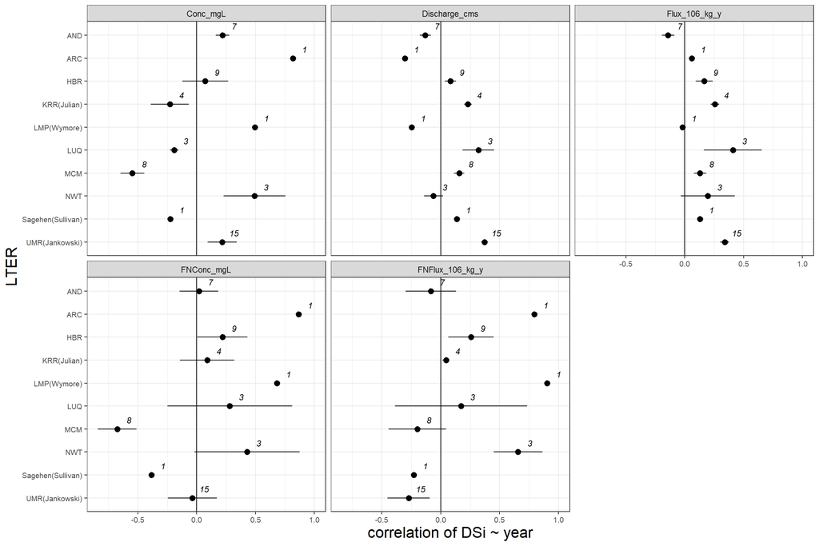

```r
ggplot(wrtds_corr, aes(LTER, ri)) +
    stat_summary(fun = mean, geom = "point") +
    stat_summary(fun.data = mean_cl_normal, geom = "pointrange", fun.args = list(mult = 1))+
  geom_hline(yintercept = 0)+
  xlab("LTER")+
  ylab("correlation of DSi ~ year")+
  stat_summary(fun.data = give.n, geom = "text", size=3, fontface="italic", position = position_nudge(x = 0.4, y=.1))+
  coord_flip()+
  scale_x_discrete(limits = rev)+
  facet_wrap(~variable)
```

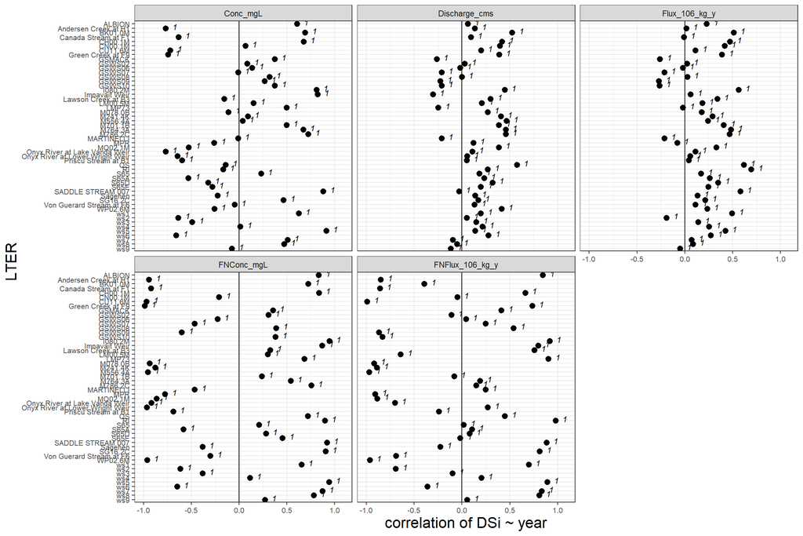

```r
ggplot(wrtds_corr, aes(site, ri)) +
    stat_summary(fun = mean, geom = "point") +
    stat_summary(fun.data = mean_cl_normal, geom = "pointrange", fun.args = list(mult = 1))+
  geom_hline(yintercept = 0)+
  xlab("LTER")+
  ylab("correlation of DSi ~ year")+
  stat_summary(fun.data = give.n, geom = "text", size=3, fontface="italic", position = position_nudge(x = 0.4, y=.1))+
  coord_flip()+
  scale_x_discrete(limits = rev)+
  facet_wrap(~variable)
```

> discharge is super correlated to flux but not conc across sites and years? does this make sense?

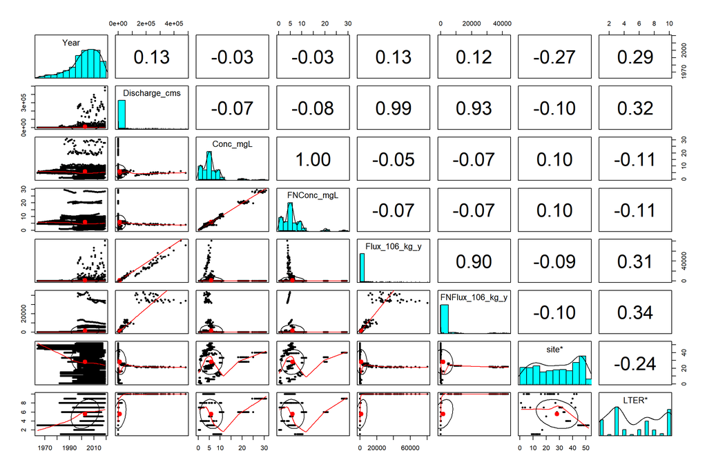

```r
pairs.panels(wrtds_annual)
```

> models using correlation data

```r
ES_wrtds <- escalc(measure="ZCOR", ri=ri, ni=ni, data=wrtds_corr)

mod1<-rma(yi=yi,vi=vi,data=filter(ES_wrtds, variable=='Discharge_cms'))
summary(mod1)
```

```
##
## Random-Effects Model (k = 52; tau^2 estimator: REML)
##
##   logLik  deviance       AIC       BIC      AICc
##   1.3614   -2.7228    1.2772    5.1409    1.5272
##
## tau^2 (estimated amount of total heterogeneity): 0.0089 (SE = 0.0098)
## tau (square root of estimated tau^2 value):      0.0944
## I^2 (total heterogeneity / total variability):   17.62%
## H^2 (total variability / sampling variability):  1.21
##
## Test for Heterogeneity:
## Q(df = 51) = 63.2050, p-val = 0.1173
##
## Model Results:
##
## estimate      se    zval    pval   ci.lb   ci.ub
##   0.1626  0.0315  5.1603  <.0001  0.1009  0.2244  ***
##
## ---
## Signif. codes:  0 '***' 0.001 '**' 0.01 '*' 0.05 '.' 0.1 ' ' 1
```

```r
mod2<-rma(yi=yi,vi=vi,data=filter(ES_wrtds, variable=='Conc_mgL'))
summary(mod2)
```

```
##
## Random-Effects Model (k = 52; tau^2 estimator: REML)
##
##   logLik  deviance       AIC       BIC      AICc
## -49.4216   98.8432  102.8432  106.7069  103.0932
##
## tau^2 (estimated amount of total heterogeneity): 0.3623 (SE = 0.0809)
## tau (square root of estimated tau^2 value):      0.6019
## I^2 (total heterogeneity / total variability):   89.68%
## H^2 (total variability / sampling variability):  9.69
##
## Test for Heterogeneity:
## Q(df = 51) = 528.5065, p-val < .0001
##
## Model Results:
##
## estimate      se    zval    pval    ci.lb   ci.ub
##   0.0619  0.0887  0.6985  0.4849  -0.1119  0.2357
##
## ---
## Signif. codes:  0 '***' 0.001 '**' 0.01 '*' 0.05 '.' 0.1 ' ' 1
```

```r
mod3<-rma(yi=yi,vi=vi,data=filter(ES_wrtds, variable=='FNConc_mgL'))
summary(mod3)
```

```
##
## Random-Effects Model (k = 52; tau^2 estimator: REML)
##
##   logLik  deviance       AIC       BIC      AICc
## -79.7092  159.4184  163.4184  167.2821  163.6684
##
## tau^2 (estimated amount of total heterogeneity): 1.2860 (SE = 0.2639)
## tau (square root of estimated tau^2 value):      1.1340
## I^2 (total heterogeneity / total variability):   96.86%
## H^2 (total variability / sampling variability):  31.83
##
## Test for Heterogeneity:
## Q(df = 51) = 1529.9495, p-val < .0001
##
## Model Results:
##
## estimate      se     zval    pval    ci.lb   ci.ub
##  -0.0859  0.1601  -0.5363  0.5917  -0.3996  0.2279
##
## ---
## Signif. codes:  0 '***' 0.001 '**' 0.01 '*' 0.05 '.' 0.1 ' ' 1
```

```r
mod3.1<-rma(yi=yi,vi=vi,data=filter(ES_wrtds, variable=='FNConc_mgL'),
            mods = ~LTER)
summary(mod3.1)
```

```
##
## Mixed-Effects Model (k = 52; tau^2 estimator: REML)
##
##   logLik  deviance       AIC       BIC      AICc
## -62.3706  124.7411  146.7411  165.8555  155.5411
##
## tau^2 (estimated amount of residual heterogeneity):     1.0938 (SE = 0.2487)
## tau (square root of estimated tau^2 value):             1.0459
## I^2 (residual heterogeneity / unaccounted variability): 96.37%
## H^2 (unaccounted variability / sampling variability):   27.52
## R^2 (amount of heterogeneity accounted for):            14.94%
##
## Test for Residual Heterogeneity:
## QE(df = 42) = 1096.5069, p-val < .0001
##
## Test of Moderators (coefficients 2:10):
## QM(df = 9) = 17.5632, p-val = 0.0406
##
## Model Results:
##
##                        estimate      se     zval    pval    ci.lb    ci.ub
## intrcpt                  0.0112  0.4030   0.0277  0.9779  -0.7787   0.8010
## LTERARC                  1.3077  1.1522   1.1349  0.2564  -0.9507   3.5660
## LTERHBR                  0.3572  0.5361   0.6663  0.5052  -0.6935   1.4079
## LTERKRR(Julian)          0.0673  0.6713   0.1003  0.9201  -1.2483   1.3830
## LTERLMP(Wymore)          0.8226  1.1546   0.7124  0.4762  -1.4405   3.0856
## LTERLUQ                  0.4282  0.7355   0.5822  0.5604  -1.0133   1.8698
## LTERMCM                 -1.3196  0.5525  -2.3885  0.0169  -2.4024  -0.2368  *
## LTERNWT                  0.7491  0.7376   1.0155  0.3098  -0.6966   2.1948
## LTERSagehen(Sullivan)   -0.4160  1.1385  -0.3654  0.7148  -2.6475   1.8154
## LTERUMR(Jankowski)      -0.2156  0.4886  -0.4413  0.6590  -1.1733   0.7420
##
## ---
## Signif. codes:  0 '***' 0.001 '**' 0.01 '*' 0.05 '.' 0.1 ' ' 1
```

> models with regression slopes

```r
wrtds_slopes <- left_join(wrtds_slopes, wrtds_corr) %>%
  mutate(mi=1) %>%
  filter(term=='Year')


wrtds_slopes_ES_Si <- escalc(measure='ZPCOR',
                          ti=statistic,
                          ni=ni,
                          mi=mi,
                          data=filter(wrtds_slopes, variable=='Conc_mgL'))

wrtds_slopes_ES_Si <- wrtds_slopes_ES_Si %>%
  arrange(LTER)

mod1<-rma.mv(yi,vi,
          data=filter(wrtds_slopes_ES_Si),
          random = ~1|site)
summary(mod1)
```

```
##
## Multivariate Meta-Analysis Model (k = 52; method: REML)
##
##   logLik  Deviance       AIC       BIC      AICc
## -49.4102   98.8205  102.8205  106.6841  103.0705
##
## Variance Components:
##
##             estim    sqrt  nlvls  fixed  factor
## sigma^2    0.3641  0.6034     52     no    site
##
## Test for Heterogeneity:
## Q(df = 51) = 549.1464, p-val < .0001
##
## Model Results:
##
## estimate      se    zval    pval    ci.lb   ci.ub
##   0.0621  0.0886  0.7005  0.4836  -0.1116  0.2358
##
## ---
## Signif. codes:  0 '***' 0.001 '**' 0.01 '*' 0.05 '.' 0.1 ' ' 1
```

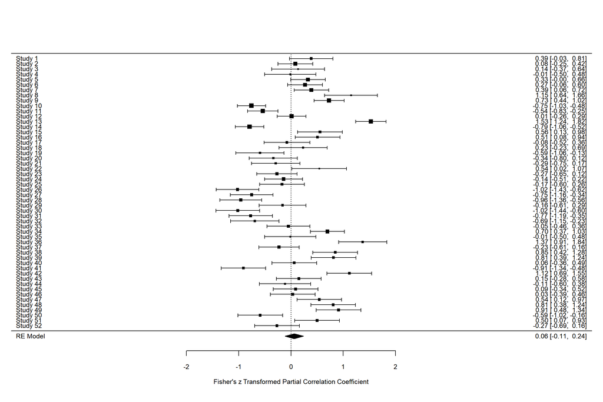

```r
forest(mod1)
```

```r
mod2<-rma.mv(yi,vi,
          data=filter(wrtds_slopes_ES_Si))
summary(mod2)
```

```
##
## Multivariate Meta-Analysis Model (k = 52; method: REML)
##
##    logLik   Deviance        AIC        BIC       AICc
## -240.9324   481.8647   483.8647   485.7965   483.9464
##
## Variance Components: none
##
## Test for Heterogeneity:
## Q(df = 51) = 549.1464, p-val < .0001
##
## Model Results:
##
## estimate      se    zval    pval    ci.lb   ci.ub
##   0.0523  0.0277  1.8867  0.0592  -0.0020  0.1066  .
##
## ---
## Signif. codes:  0 '***' 0.001 '**' 0.01 '*' 0.05 '.' 0.1 ' ' 1
```

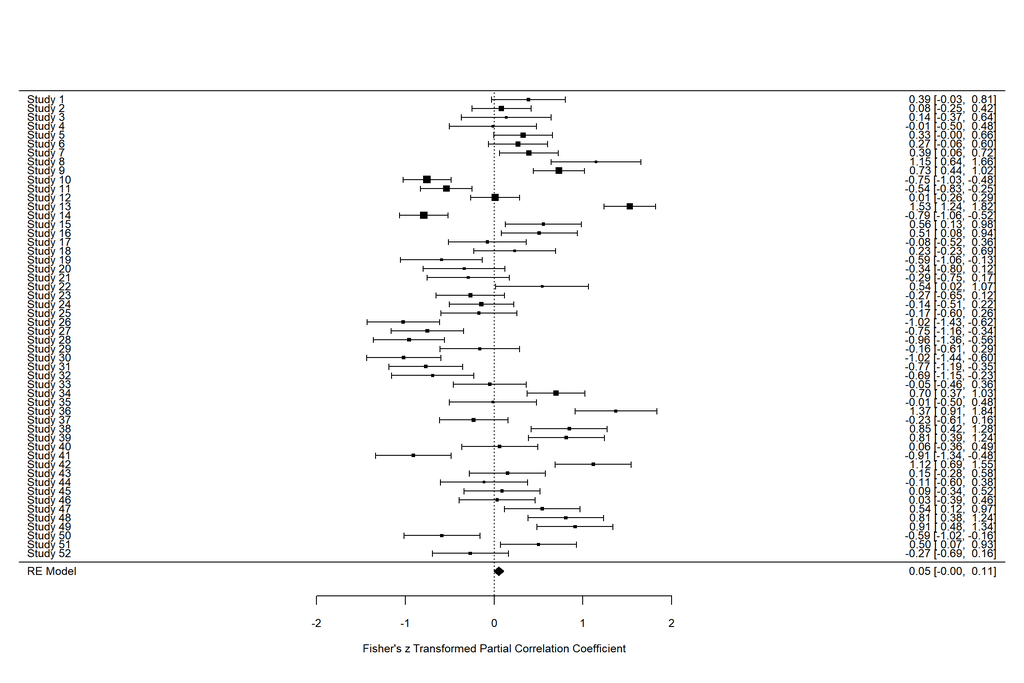

[figure not shown]

```r
forest(mod2)

viz_forest(x = wrtds_slopes_ES_Si[, c("yi", "vi")],
           study_labels = wrtds_slopes_ES_Si[, "site"],
           xlab = "Slope of Si by year",
           variant = "thick",
           group=wrtds_slopes_ES_Si[, "LTER"],
           method = "DL",
           annotate_CI = TRUE,
           summary_label = c("Summary(LTER = AND)",
                  "Summary(LTER = ARC)",
                  "Summary(LTER = KRR(Julian))",
                  "Summary(LTER = HBR)",
                  "Summary(LTER = LMP(Wymore))",
                  "Summary(LTER = LUQ)",
                  "Summary (LTER = MCM)",
                  "Summary (LTER = NWT)",
                   "Summary(LTER = Sagehen(Sullivan))",
                   "Summary(LTER = UMR(Jankowski))"))
```

> forest plots for each LTER and another attempt to combine them all

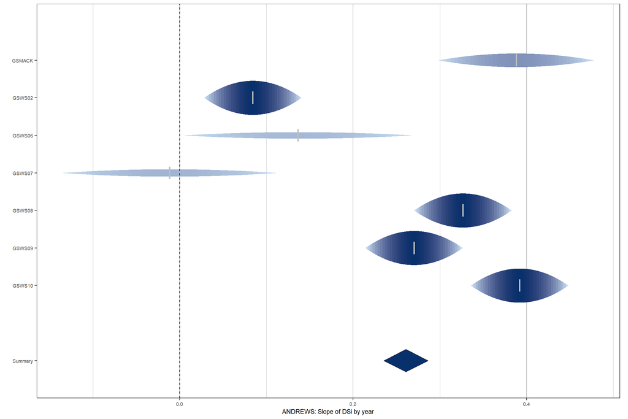

```r
a <- viz_forest(x = filter(wrtds_slopes_ES_Si, LTER=="AND")[, c("yi", "vi")],
           study_labels = filter(wrtds_slopes_ES_Si, LTER=="AND")[, "site"],
           xlab = "ANDREWS: Slope of DSi by year",
           variant = "rain")
a
```

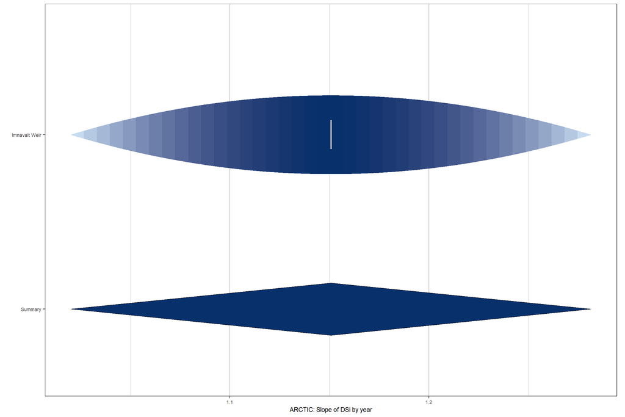

```r
b <- viz_forest(x = filter(wrtds_slopes_ES_Si, LTER=="ARC")[, c("yi", "vi")],
           study_labels = filter(wrtds_slopes_ES_Si, LTER=="ARC")[, "site"],
           xlab = "ARCTIC: Slope of DSi by year",
           variant = "rain")
b
```

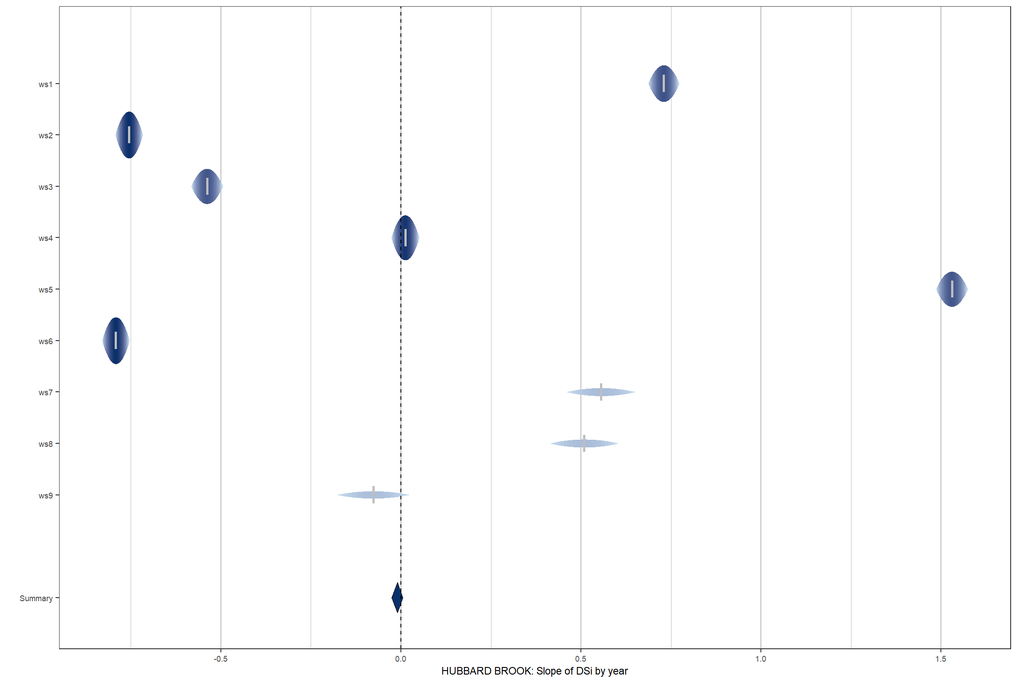

```r
c <- viz_forest(x = filter(wrtds_slopes_ES_Si, LTER=="HBR")[, c("yi", "vi")],
           study_labels = filter(wrtds_slopes_ES_Si, LTER=="HBR")[, "site"],
           xlab = "HUBBARD BROOK: Slope of DSi by year",
           variant = "rain")
c
```

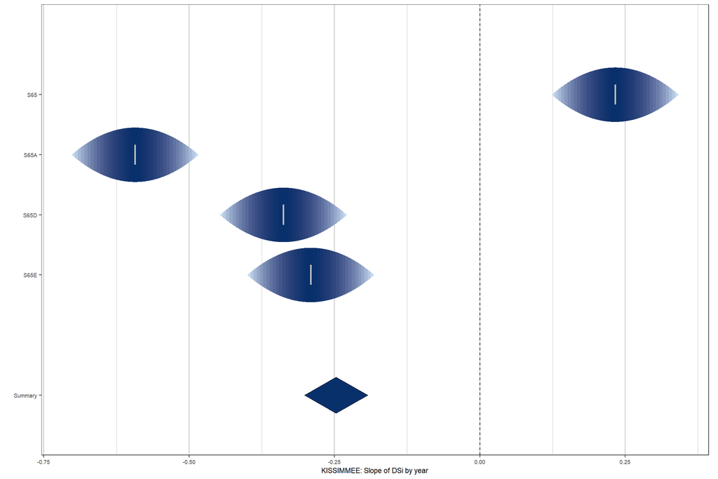

```r
d <- viz_forest(x = filter(wrtds_slopes_ES_Si, LTER=="KRR(Julian)")[, c("yi", "vi")],
           study_labels = filter(wrtds_slopes_ES_Si, LTER=="KRR(Julian)")[, "site"],
           xlab = "KISSIMMEE: Slope of DSi by year",
           variant = "rain")
d
```

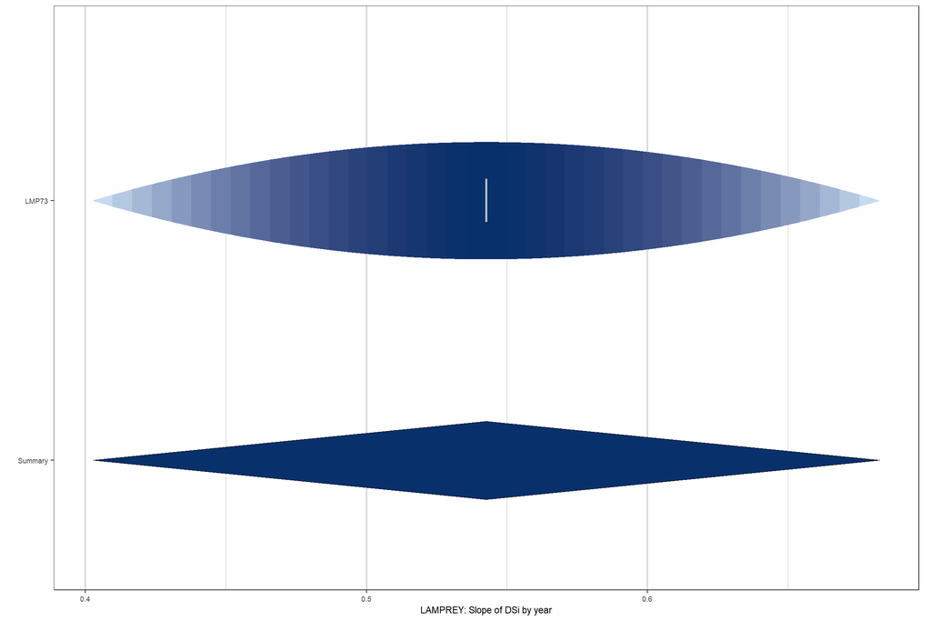

```r
e <- viz_forest(x = filter(wrtds_slopes_ES_Si, LTER=="LMP(Wymore)")[, c("yi", "vi")],
           study_labels = filter(wrtds_slopes_ES_Si, LTER=="LMP(Wymore)")[, "site"],
           xlab = "LAMPREY: Slope of DSi by year",
           variant = "rain")
e
```

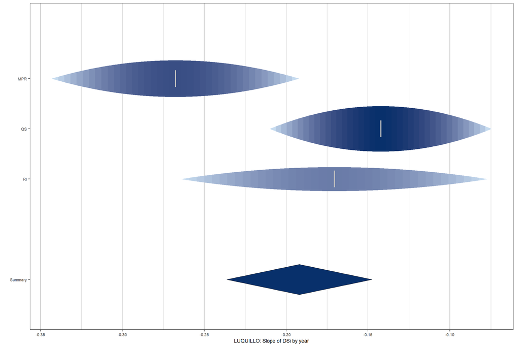

```r
f <- viz_forest(x = filter(wrtds_slopes_ES_Si, LTER=="LUQ")[, c("yi", "vi")],
           study_labels = filter(wrtds_slopes_ES_Si, LTER=="LUQ")[, "site"],
           xlab = "LUQUILLO: Slope of DSi by year",
           variant = "rain")
f
```

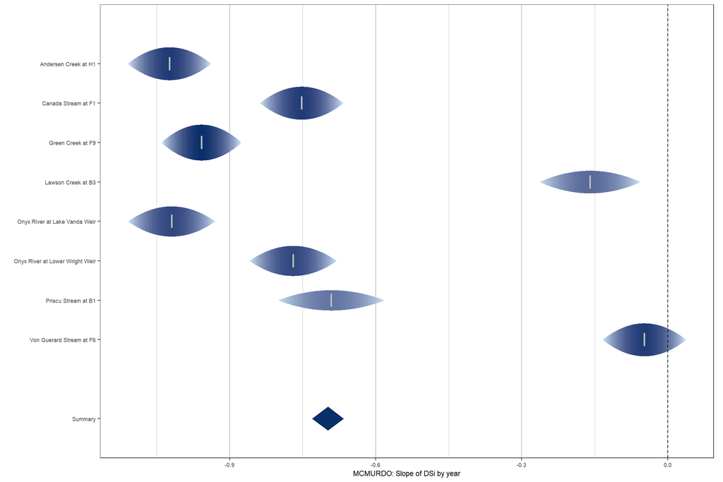

```r
g <- viz_forest(x = filter(wrtds_slopes_ES_Si, LTER=="MCM")[, c("yi", "vi")],
           study_labels = filter(wrtds_slopes_ES_Si, LTER=="MCM")[, "site"],
           xlab = "MCMURDO: Slope of DSi by year",
           variant = "rain")
g
```

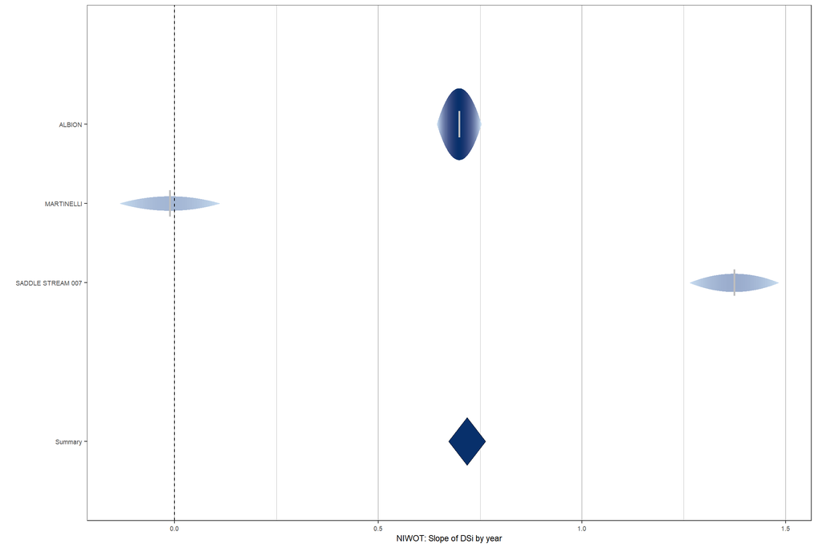

```r
h <- viz_forest(x = filter(wrtds_slopes_ES_Si, LTER=="NWT")[, c("yi", "vi")],
           study_labels = filter(wrtds_slopes_ES_Si, LTER=="NWT")[, "site"],
           xlab = "NIWOT: Slope of DSi by year",
           variant = "rain")
h
```

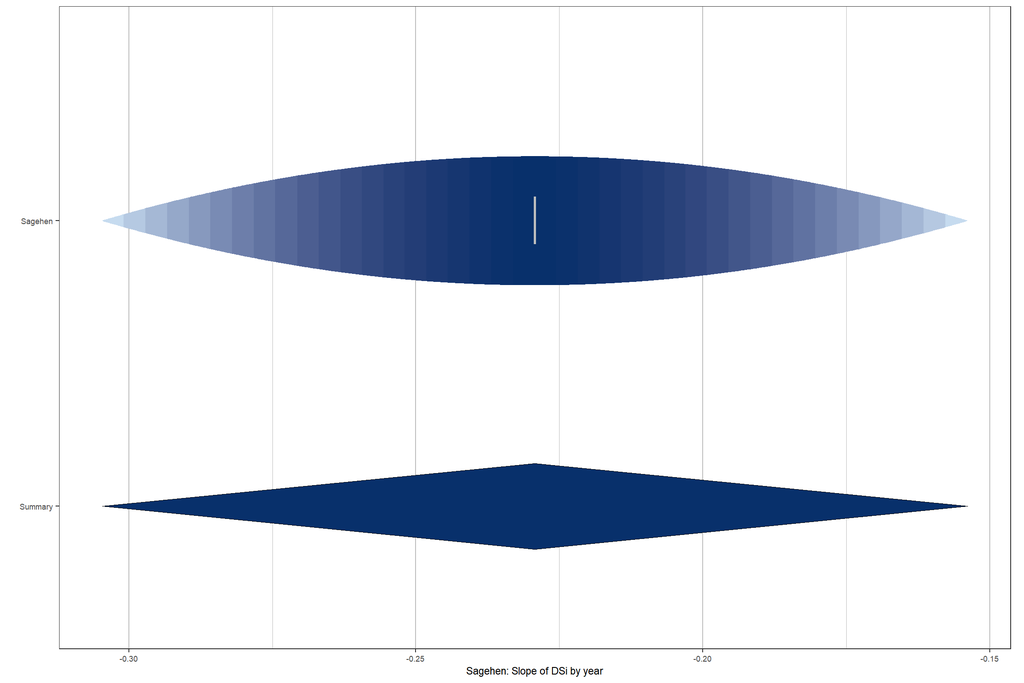

```r
i <- viz_forest(x = filter(wrtds_slopes_ES_Si, LTER=="Sagehen(Sullivan)")[, c("yi", "vi")],
           study_labels = filter(wrtds_slopes_ES_Si, LTER=="Sagehen(Sullivan)")[, "site"],
           xlab = "Sagehen: Slope of DSi by year",
           variant = "rain")
i
```

[figure not shown]

```r
j <- viz_forest(x = filter(wrtds_slopes_ES_Si, LTER=="UMR(Jankowski)")[, c("yi", "vi")],
           study_labels = filter(wrtds_slopes_ES_Si, LTER=="UMR(Jankowski)")[, "site"],
           xlab = "Sagehen: Slope of DSi by year",
           variant = "rain")
j
```

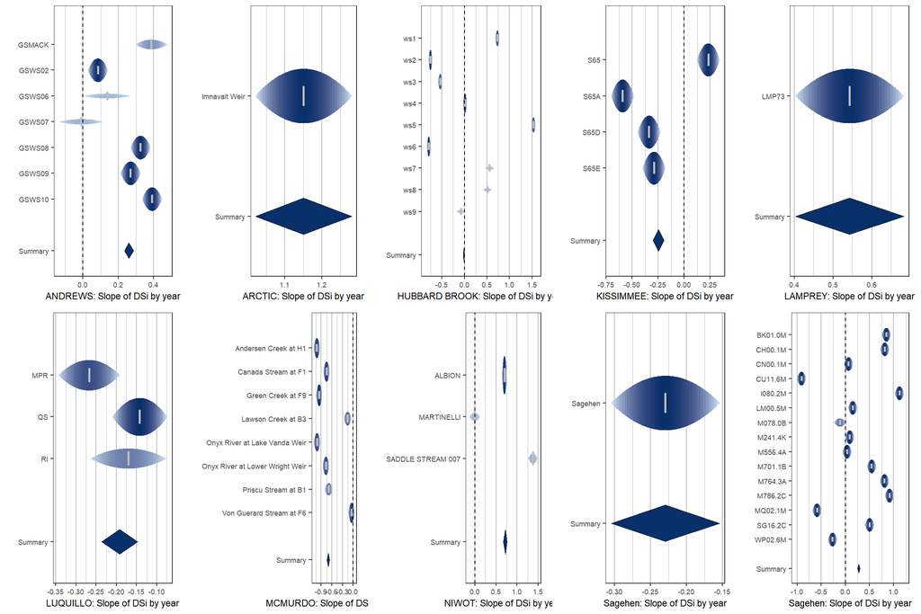

```r
ggarrange(a,b,c,d,e,f,g,h,i,j, ncol=5, nrow=2)
```

[figure not shown]

```r
viz_forest(x = wrtds_slopes_ES_Si[, c("yi", "vi")],
           xlab = "HUBBARD BROOK: Slope of DSi by year",
           group=wrtds_slopes_ES_Si[, "LTER"],
           variant = "rain",
           summary_label = c("Summary(LTER = AND)",
                  "Summary(LTER = ARC)",
                  "Summary(LTER = KRR(Julian))",
                  "Summary(LTER = HBR)",
                  "Summary(LTER = LMP(Wymore))",
                  "Summary(LTER = LUQ)",
                  "Summary (LTER = MCM)",
                  "Summary (LTER = NWT)",
                   "Summary(LTER = Sagehen(Sullivan))",
                   "Summary(LTER = UMR(Jankowski))"))
```

```r
# fit <- nlme(data=wrtds, FNConc_mgL ~ Year, random = ~LTER)
#
# fit <- lmer(data=wrtds2, FNConc_mgL ~ Year +1|LTER)
# summary(fit)
```

# 3 Using WRTDS trend estimates

> hmm some have 95% CIs in the 90 million-ish range so let’s scrap those for now

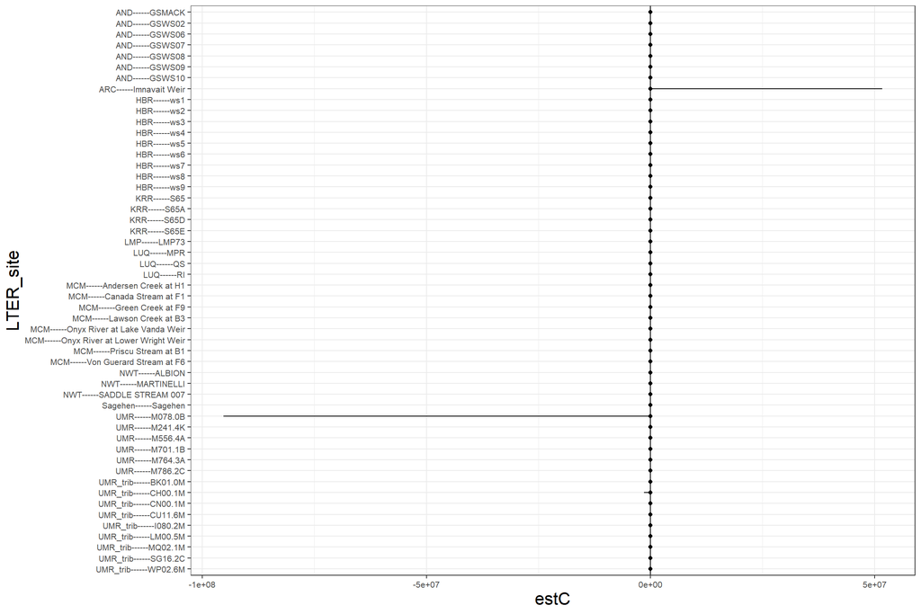

```r
ggplot(wrtds_trends, aes(LTER_site, estC)) +
  geom_point()+
  geom_linerange(aes(ymin = lowC95, ymax = upC95))+
  coord_flip()+
  geom_hline(yintercept = 0)+
  scale_x_discrete(limits = rev)
```

```r
wrtds_trends %>%
  arrange(lowC95)
```

```
## # A tibble: 52 x 33
##    LTER  site  rejectC  pValC   estC     lowC    upC   lowC50  upC50  lowC95
##    <chr> <chr> <lgl>    <dbl>  <dbl>    <dbl>  <dbl>    <dbl>  <dbl>   <dbl>
##  1 UMR   M078~ FALSE   0.146  -0.446 -9.46e+7  0.236 -8.71e-1 -0.449 -9.53e7
##  2 UMR_~ CH00~ FALSE   0.503   0.305 -4.94e-1  1.15  -2.63e-3  0.720 -1.47e6
##  3 UMR_~ CU11~ FALSE   0.271  -0.771 -2.00e+0  0.743 -1.23e+0 -0.358 -2.36e5
##  4 UMR_~ LM00~ FALSE   0.584   0.146 -7.68e-1  0.906 -1.24e-1  0.536 -1.67e5
##  5 LUQ   RI    FALSE   0.886   1.33  -2.28e+4  5.66  -1.69e+4  2.16  -2.55e4
##  6 Sage~ Sage~ TRUE    0.0198 -1.41  -2.14e+4 -0.720 -2.09e+4 -1.21  -2.18e4
##  7 NWT   MART~ TRUE    0.0944  0.263  3.73e-2  0.414  1.65e-1  0.325 -1.77e4
##  8 ARC   Imna~ FALSE   0.795   0.553 -6.63e+0 13.1   -5.95e-1  0.718 -3.69e1
##  9 NWT   SADD~ FALSE   0.374   5.34  -5.51e+0 10.2    1.23e+0  6.97  -1.75e1
## 10 LUQ   MPR   FALSE   0.834  -0.246 -4.98e+0  3.25  -2.94e+0  0.786 -6.74e0
## # ... with 42 more rows, and 23 more variables: upC95 <dbl>, likeCUp <dbl>,
## #   likeCDown <dbl>, rejectF <lgl>, pValF <dbl>, estF <dbl>, lowF <dbl>,
## #   upF <dbl>, lowF50 <dbl>, upF50 <dbl>, lowF95 <dbl>, upF95 <dbl>,
## #   likeFUp <dbl>, likeFDown <dbl>, baseConc <dbl>, baseFlux <dbl>,
## #   iBoot <dbl>, startSeed <dbl>, nBootGood <dbl>, Year.1 <dbl>, Year.2 <dbl>,
## #   duration <dbl>, LTER_site <chr>
```

```r
wrtds_trends %>%
  arrange(desc(upC95))
```

```
## # A tibble: 52 x 33
##    LTER  site  rejectC  pValC   estC     lowC   upC   lowC50  upC50   lowC95
##    <chr> <chr> <lgl>    <dbl>  <dbl>    <dbl> <dbl>    <dbl>  <dbl>    <dbl>
##  1 ARC   Imna~ FALSE   0.795   0.553 -6.63e+0 13.1  -5.95e-1  0.718 -3.69e+1
##  2 NWT   SADD~ FALSE   0.374   5.34  -5.51e+0 10.2   1.23e+0  6.97  -1.75e+1
##  3 LUQ   RI    FALSE   0.886   1.33  -2.28e+4  5.66 -1.69e+4  2.16  -2.55e+4
##  4 UMR_~ WP02~ FALSE   0.433  -1.52  -2.10e+0  1.44 -1.63e+0 -0.157 -2.37e+0
##  5 LUQ   MPR   FALSE   0.834  -0.246 -4.98e+0  3.25 -2.94e+0  0.786 -6.74e+0
##  6 MCM   Ande~ FALSE   0.339  -0.309 -6.11e-1  2.30 -4.52e-1 -0.120 -7.45e-1
##  7 UMR_~ BK01~ FALSE   0.138   0.482 -9.85e-2  1.69  2.74e-1  1.04  -3.44e-1
##  8 KRR   S65E  FALSE   0.602   0.280 -2.36e+0  1.52 -2.62e-1  1.01  -3.18e+0
##  9 UMR_~ CN00~ FALSE   0.504   0.223 -4.01e-1  1.57 -1.16e-2  0.970 -6.30e-1
## 10 LUQ   QS    TRUE    0.0392  0.990  4.70e-1  1.64  7.72e-1  1.26   2.13e-1
## # ... with 42 more rows, and 23 more variables: upC95 <dbl>, likeCUp <dbl>,
## #   likeCDown <dbl>, rejectF <lgl>, pValF <dbl>, estF <dbl>, lowF <dbl>,
## #   upF <dbl>, lowF50 <dbl>, upF50 <dbl>, lowF95 <dbl>, upF95 <dbl>,
## #   likeFUp <dbl>, likeFDown <dbl>, baseConc <dbl>, baseFlux <dbl>,
## #   iBoot <dbl>, startSeed <dbl>, nBootGood <dbl>, Year.1 <dbl>, Year.2 <dbl>,
## #   duration <dbl>, LTER_site <chr>
```

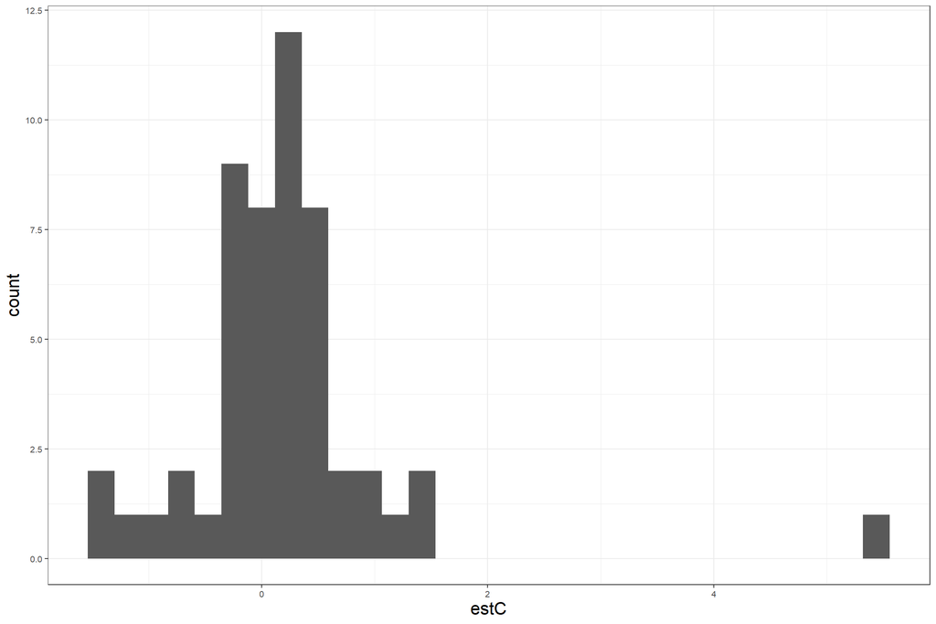

```r
ggplot(wrtds_trends, aes(estC))+
  geom_histogram()
```

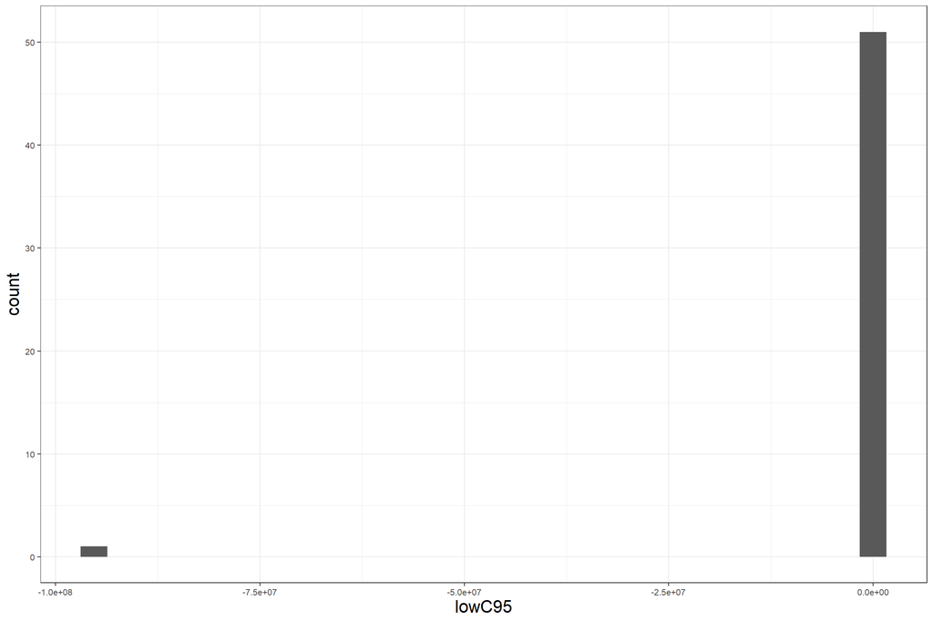

```r
ggplot(wrtds_trends, aes(lowC95))+
  geom_histogram()
```

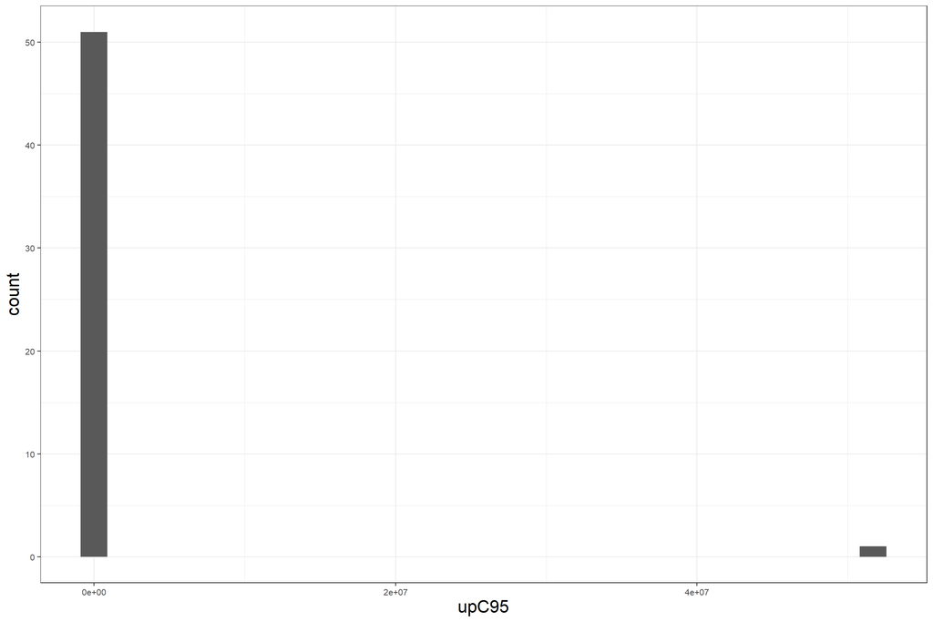

```r
ggplot(wrtds_trends, aes(upC95))+
  geom_histogram()
```

```r
wrtds_trends %>%
  filter(lowC95 < -2e7)
```

```
## # A tibble: 1 x 33
##   LTER  site  rejectC pValC   estC    lowC   upC lowC50  upC50  lowC95 upC95
##   <chr> <chr> <lgl>   <dbl>  <dbl>   <dbl> <dbl>  <dbl>  <dbl>   <dbl> <dbl>
## 1 UMR   M078~ FALSE   0.146 -0.446 -9.46e7 0.236 -0.871 -0.449 -9.53e7 0.906
## # ... with 22 more variables: likeCUp <dbl>, likeCDown <dbl>, rejectF <lgl>,
## #   pValF <dbl>, estF <dbl>, lowF <dbl>, upF <dbl>, lowF50 <dbl>, upF50 <dbl>,
## #   lowF95 <dbl>, upF95 <dbl>, likeFUp <dbl>, likeFDown <dbl>, baseConc <dbl>,
## #   baseFlux <dbl>, iBoot <dbl>, startSeed <dbl>, nBootGood <dbl>,
## #   Year.1 <dbl>, Year.2 <dbl>, duration <dbl>, LTER_site <chr>
```

```r
wrtds_trends %>%
  filter(upC95 > 2e7)
```

```
## # A tibble: 1 x 33
##   LTER  site  rejectC pValC  estC  lowC   upC lowC50 upC50 lowC95  upC95 likeCUp
##   <chr> <chr> <lgl>   <dbl> <dbl> <dbl> <dbl>  <dbl> <dbl>  <dbl>  <dbl>   <dbl>
## 1 ARC   Imna~ FALSE   0.795 0.553 -6.63  13.1 -0.595 0.718  -36.9 5.17e7      NA
## # ... with 21 more variables: likeCDown <dbl>, rejectF <lgl>, pValF <dbl>,
## #   estF <dbl>, lowF <dbl>, upF <dbl>, lowF50 <dbl>, upF50 <dbl>, lowF95 <dbl>,
## #   upF95 <dbl>, likeFUp <dbl>, likeFDown <dbl>, baseConc <dbl>,
## #   baseFlux <dbl>, iBoot <dbl>, startSeed <dbl>, nBootGood <dbl>,
## #   Year.1 <dbl>, Year.2 <dbl>, duration <dbl>, LTER_site <chr>
```

```r
wrtds_trends_trimmed <- wrtds_trends %>%
  filter(lowC95>-50) %>%
  filter(upC95<50)
```

```r
summary(wrtds_trends_trimmed)
```

```
##      LTER               site            rejectC            pValC
##  Length:44          Length:44          Mode :logical   Min.   :0.01980
##  Class :character   Class :character   FALSE:33        1st Qu.:0.09864
##  Mode  :character   Mode  :character   TRUE :11        Median :0.23482
##                                                        Mean   :0.33119
##                                                        3rd Qu.:0.51405
##                                                        Max.   :0.97723
##
##       estC              lowC              upC               lowC50
##  Min.   :-1.5187   Min.   :-5.5108   Min.   :-0.01031   Min.   :-2.94079
##  1st Qu.:-0.1363   1st Qu.:-0.5729   1st Qu.: 0.35689   1st Qu.:-0.25621
##  Median : 0.1965   Median :-0.2876   Median : 0.86837   Median :-0.05223
##  Mean   : 0.2363   Mean   :-0.6132   Mean   : 1.10630   Mean   :-0.08456
##  3rd Qu.: 0.4931   3rd Qu.:-0.1114   3rd Qu.: 1.38779   3rd Qu.: 0.30061
##  Max.   : 5.3402   Max.   : 0.9813   Max.   :10.16405   Max.   : 1.23391
##
##      upC50              lowC95             upC95             likeCUp
##  Min.   :-0.58212   Min.   :-17.5133   Min.   : 0.02856   Min.   :0.02778
##  1st Qu.:-0.01424   1st Qu.: -0.9011   1st Qu.: 0.43535   1st Qu.:0.25490
##  Median : 0.42081   Median : -0.4742   Median : 1.13162   Median :0.71569
##  Mean   : 0.55089   Mean   : -1.1159   Mean   : 1.37864   Mean   :0.60333
##  3rd Qu.: 0.85097   3rd Qu.: -0.2064   3rd Qu.: 1.63045   3rd Qu.:0.94059
##  Max.   : 6.97374   Max.   :  0.8973   Max.   :10.41049   Max.   :0.99505
##                                                           NA's   :1
##    likeCDown         rejectF            pValF             estF
##  Min.   :0.004951   Mode :logical   Min.   :0.0198   Min.   :-10352.558
##  1st Qu.:0.059406   FALSE:34        1st Qu.:0.1570   1st Qu.:    -0.056
##  Median :0.284314   TRUE :10        Median :0.4122   Median :     0.033
##  Mean   :0.396673                   Mean   :0.4393   Mean   :  -303.418
##  3rd Qu.:0.745098                   3rd Qu.:0.6886   3rd Qu.:     6.917
##  Max.   :0.972222                   Max.   :0.9244   Max.   :   278.731
##  NA's   :1
##       lowF                 upF               lowF50
##  Min.   :-20645.685   Min.   :   0.002   Min.   :-13299.324
##  1st Qu.:   -16.438   1st Qu.:   0.133   1st Qu.:    -0.797
##  Median :    -0.205   Median :   0.769   Median :    -0.002
##  Mean   :  -697.895   Mean   : 302.531   Mean   :  -432.513
##  3rd Qu.:    -0.002   3rd Qu.:  53.948   3rd Qu.:     0.241
##  Max.   :    33.868   Max.   :5488.965   Max.   :   196.891
##
```

[output cut: 17 more lines]

```
##  Min.   :494817   Min.   : 50.00   Min.   :1964   Min.   :2012
##  1st Qu.:494817   1st Qu.: 50.00   1st Qu.:1984   1st Qu.:2017
##  Median :494817   Median : 50.00   Median :1995   Median :2018
##  Mean   :494817   Mean   : 61.93   Mean   :1991   Mean   :2018
##  3rd Qu.:494817   3rd Qu.: 59.50   3rd Qu.:1997   3rd Qu.:2019
##  Max.   :494817   Max.   :100.00   Max.   :2003   Max.   :2019
##
##     duration      LTER_site
##  Min.   :15.00   Length:44
##  1st Qu.:21.75   Class :character
##  Median :22.00   Mode  :character
##  Mean   :27.00
##  3rd Qu.:31.50
##  Max.   :53.00
##
```

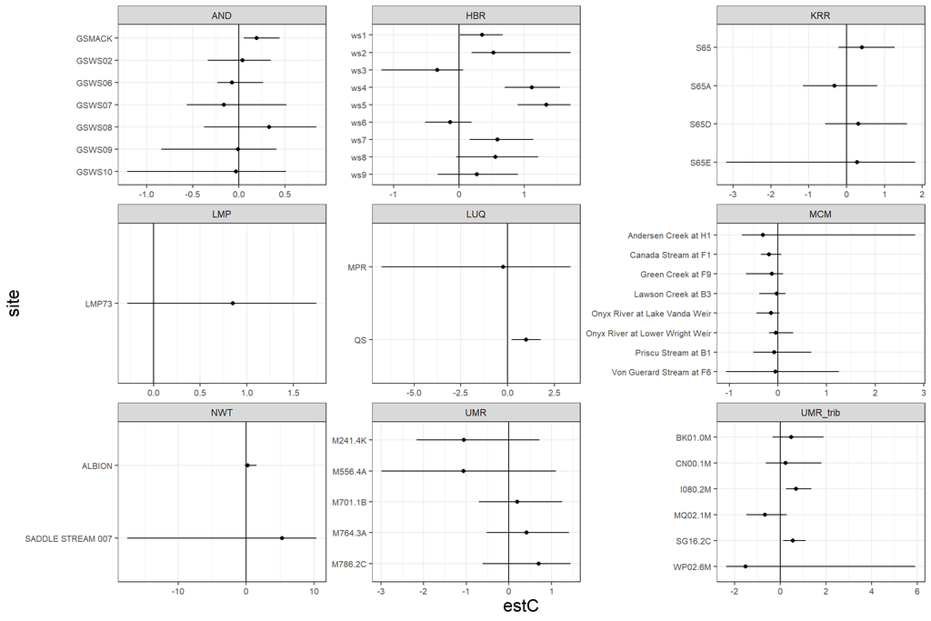

```r
ggplot(wrtds_trends_trimmed, aes(site, estC)) +
  geom_point()+
  geom_linerange(aes(ymin = lowC95, ymax = upC95))+
  coord_flip()+
  geom_hline(yintercept = 0)+
  scale_x_discrete(limits = rev)+
  facet_wrap(~LTER, scales='free')
```

```r
#trying to make summary points per LTER didn't work this way

# ggplot(wrtds_trends_trimmed) +
#   geom_point(aes(site, estC))+
#   geom_linerange(aes(site, ymin = lowC95, ymax = upC95))+
#   coord_flip()+
#   geom_hline(yintercept = 0)+
#   scale_x_discrete(limits = rev)+
#   stat_summary(aes(LTER, fun = mean, geom = "point")) +
#   stat_summary(aes(LTER, fun.data = mean_cl_normal,
#                geom = "pointrange", fun.args = list(mult = 1)))+
#   facet_wrap(~LTER, scales='free')
```

> calculating a rough estimate of standard error from the 95% CIs for now, but need to make sure this is ok to do (should still give a relatively good weighting for meta-regression stuff for now/makes sense when compared to the CIs)

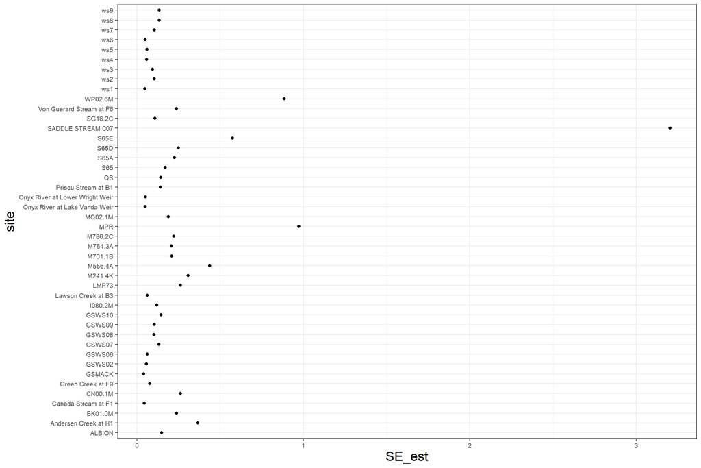

```r
wrtds_trends_trimmed <- wrtds_trends_trimmed %>%
  mutate(SE_est = ((upC95-lowC95)/2)/sqrt(duration))

ggplot(wrtds_trends_trimmed, aes(site, SE_est))+
  geom_point()+
  coord_flip()
```

> trying to do a meta-regression model for each LTER because that’s the only way I know how to get overall weighted effect sizes for each LTER, but metafor doesn’t like whatever I’m doing

> likelihood vs pval stuff to check out how those are all related

```r
wrtds_trends %>% count(rejectC)
```

```
## # A tibble: 2 x 2
##   rejectC     n
##   <lgl>   <int>
## 1 FALSE      39
## 2 TRUE       13
```

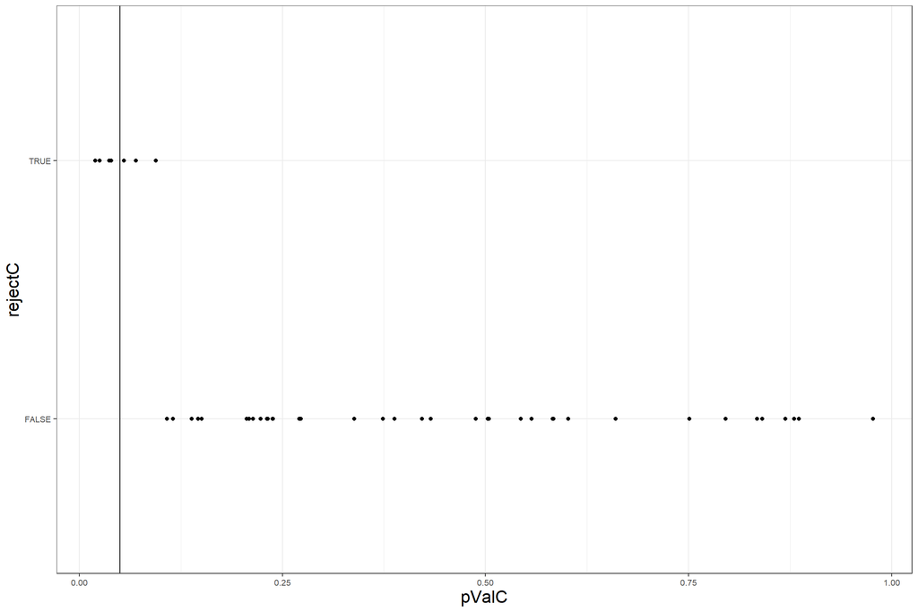

```r
ggplot(wrtds_trends, aes(pValC, rejectC))+
  geom_point()+
  geom_vline(xintercept=.05)
```

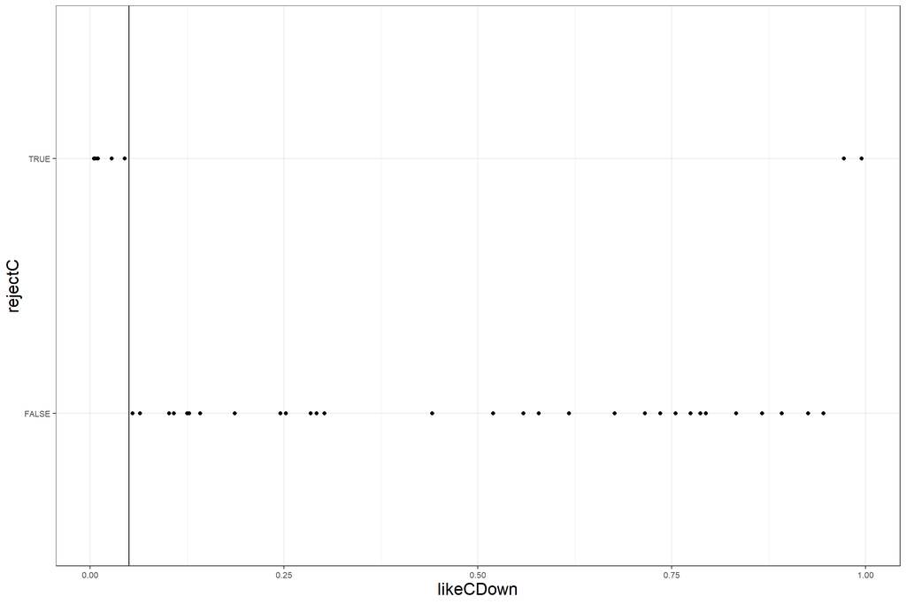

```r
ggplot(wrtds_trends, aes(likeCDown, rejectC))+
  geom_point()+
  geom_vline(xintercept=.05)
```

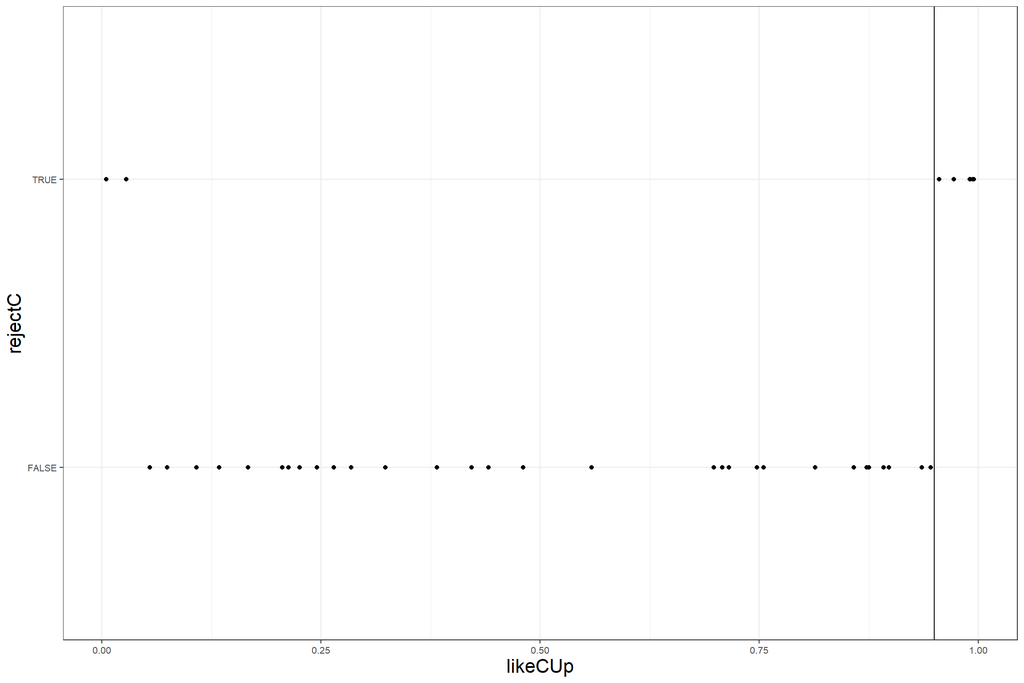

```r
ggplot(wrtds_trends, aes(likeCUp, rejectC))+
  geom_point()+
  geom_vline(xintercept=.95)
```

# 4 maps

> importing lat-long data and having a quick look- looks like Sagehen needs to swap hemispheres

```r
latlongs <- read_csv("LongTermWatersheds_LatLong.csv") %>%
  rename(site=Stream.Site)

leaflet(latlongs) %>%
  addTiles() %>%
  addMarkers(lng = ~Longitude, lat = ~Latitude, popup = ~ LTER)
```

[interactive chart not shown]

```r
latlongs <- latlongs %>%
  mutate(Longitude = ifelse(LTER=='Sagehen', -Longitude, Longitude))

leaflet(latlongs) %>%
  addTiles() %>%
  addMarkers(lng = ~Longitude, lat = ~Latitude, popup = ~ LTER)
```

[interactive chart not shown]

```r
a <- unique(wrtds_trends$site) #usi this to check where there are differences in the colnames
b <- unique(latlongs$site)
setdiff(b,a)
```

```
## [1] "TW Weir"      "Toolik Inlet" "Q1"           "Q2"           "Q3"
## [6] "QP"
```

```r
b %in% a
```

```
##  [1]  TRUE  TRUE  TRUE  TRUE  TRUE  TRUE  TRUE  TRUE FALSE FALSE  TRUE  TRUE
## [13]  TRUE  TRUE  TRUE  TRUE  TRUE  TRUE  TRUE  TRUE  TRUE  TRUE  TRUE  TRUE
## [25]  TRUE  TRUE  TRUE FALSE FALSE FALSE FALSE  TRUE  TRUE  TRUE  TRUE  TRUE
## [37]  TRUE  TRUE  TRUE  TRUE  TRUE  TRUE  TRUE  TRUE  TRUE  TRUE  TRUE  TRUE
## [49]  TRUE  TRUE  TRUE  TRUE  TRUE  TRUE  TRUE  TRUE  TRUE  TRUE
```

```r
which(a %in% b)
```

```
##  [1]  1  2  3  4  5  6  7  8  9 10 11 12 13 14 15 16 17 18 19 20 21 22 23 24 25
## [26] 26 27 28 29 30 31 32 33 34 35 36 37 38 39 40 41 42 43 44 45 46 47 48 49 50
## [51] 51 52
```

```r
wrtds_trends2 <- left_join(wrtds_trends, latlongs, by='site')
```

> joining with slope data

```r
pal <- colorBin(palette = "RdBu", bins = c(-6,-3,-2,-1,0,1,2,3,6), domain = wrtds_trends$estC, reverse = TRUE)

#pal <- colorNumeric("RdBu", wrtds_trends$estC)

leaflet(wrtds_trends2) %>%
  addTiles() %>%
  addCircleMarkers(lng = ~Longitude,
             lat = ~Latitude,
             #popup = ~ LTER.x,
             color="black",
             stroke=TRUE,
             fillColor = ~pal(estC),
             fillOpacity = 10,
             opacity = .5,
             label = ~paste0(wrtds_trends2$LTER.x,"::", wrtds_trends2$site, ", slope: ", estC),
             radius = 10) %>%
  addLegend(position = "bottomleft",
                  pal = pal,
                  values = range(wrtds_trends$estC),
                  title = "WRTDS slope estimate (DSi~year)")
```

[interactive chart not shown]